# Advanced R

Michael Liou

12/6/2021

# Plotting in R

The interface of plotting is powered by the package `grid`

## grid package

- grobs : graphical object
- viewports: defining regions where to plot

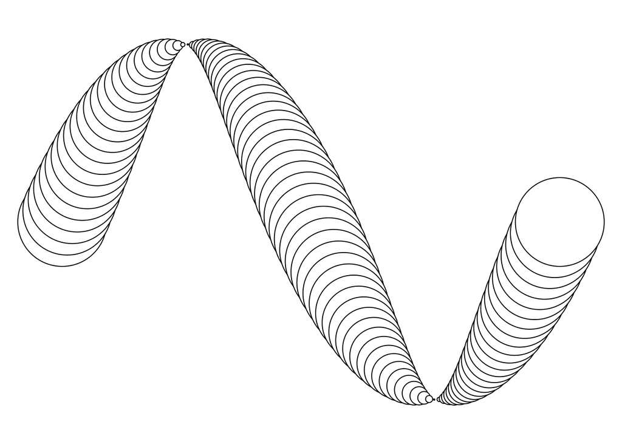

```r
grid.circle(x=seq(0.1, 0.9, length=100), # position
            y=0.5 + 0.4*sin(seq(0, 2*pi, length=100)),
            r=abs(0.1*cos(seq(0, 2*pi, length=100))))
```

### viewports

viewports are “drawing contexts”, basically defining regions of plotting.

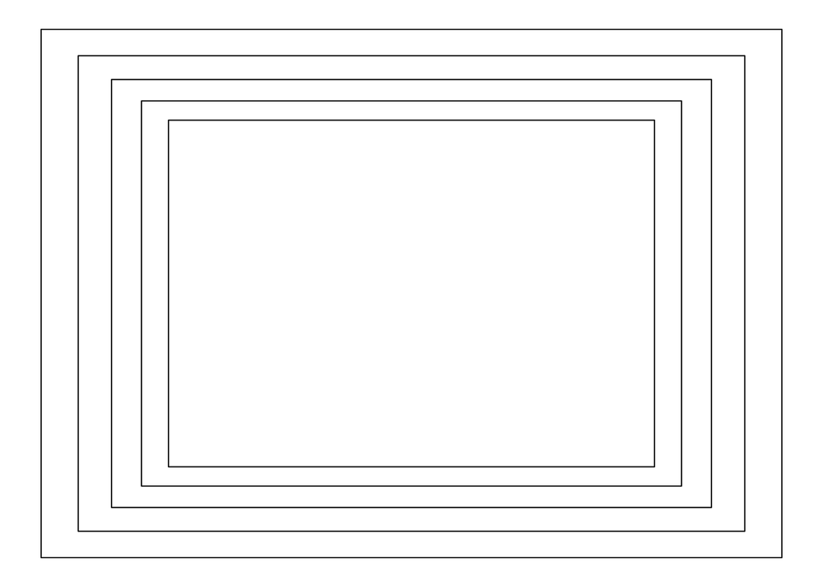

```r
# An easy first example
grid.newpage()
vp1 <- viewport(x = .5, y = .5,
                height = .9, width = .9,
                xscale=c(0,1), yscale=c(0,1))

for (i in 1:5) {
 pushViewport(vp1)
 grid.rect()
}
```

```r
# current.vpTree() # check the drawing context
```

What’s going on here?!

Example of recreating a scatter plot

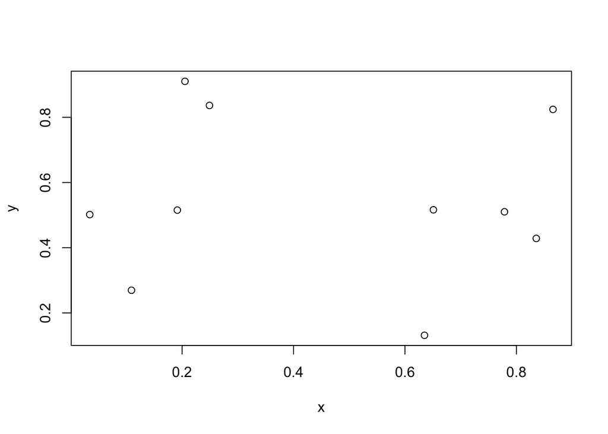

```r
x <- runif(10)
y <- runif(10)
plot(x, y)
```

Looking above, we can decompose the plot into 9 sections,

```r
# first layer
main_vp <- viewport(layout = grid.layout(3, 3,
                                         widths = unit(c(5, 1, 2), c("lines", "null", "lines")),
                                         heights = unit(c(5, 1, 2), c("lines", "null", "lines"))),
                    name = "main")

# second layer
mr_vp <- viewport(layout.pos.row = 2, layout.pos.col = 3, name = "margin_right")
mb_vp <- viewport(layout.pos.row = 3, layout.pos.col = 2, name = "margin_bottom")
mt_vp <- viewport(layout.pos.row = 1, layout.pos.col = 2, name = "margin_top")
ml_vp <- viewport(layout.pos.row = 2, layout.pos.col = 3, name = "margin_left")
center_vp <- viewport(layout.pos.row = 2, layout.pos.col = 2, name = "center",
                      xscale = extendrange(x),
                      yscale = extendrange(y))

# create the viewport
splot <- vpTree(main_vp, vpList(mr_vp, mb_vp, mt_vp, ml_vp, center_vp))
splot # Currently just the description, and not associated with the graphics device
```

```
## viewport[main]->(viewport[margin_right], viewport[margin_bottom], viewport[margin_top], viewport[margin_left], viewport[center])
```

```r
# viewport of current device
current.vpTree() # current vp tree of graphic device
```

```
## viewport[ROOT]
```

```r
current.viewport() # This is the current viewport LAYER (in the tree) of our graphics device
```

```
## viewport[ROOT]
```

```r
# In order to make the viewport splot active, we must add it to the vpTree of our device
pushViewport(splot)
current.vpTree() # notice how our tree has changed
```

```
## viewport[ROOT]->(viewport[main]->(viewport[margin_right], viewport[margin_top], viewport[margin_left], viewport[margin_bottom], viewport[center]))
```

```r
current.viewport() # our current layer is center
```

```
## viewport[center]
```

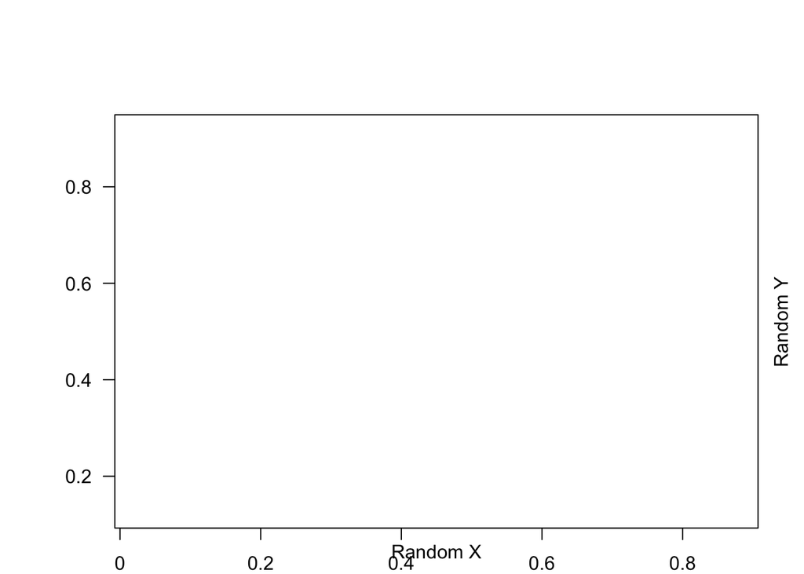

```r
grid.points(x, y) # drawn to center, for some reason this isn't showing up
grid.xaxis()
grid.yaxis()
grid.rect()

# navigate to bottom margin
seekViewport("margin_bottom")
grid.text("Random X", y=unit(1, "lines"))

seekViewport("margin_left")
grid.text("Random Y", x=unit(1, "lines"), rot = 90)
```

Run all the code all at once, rmarkdown does some weird stuff with viewports

```r
pushViewport(viewport())
upViewport()
pushViewport(viewport(name = "A"))
upViewport()
pushViewport(viewport(name = "B"))
upViewport()
```

```r
current.vpTree()
```

```
## viewport[ROOT]->(viewport[GRID.VP.2], viewport[A], viewport[B])
```

## gtable

[Unofficial Guide](https://cran.r-project.org/web/packages/gridExtra/vignettes/gtable.html)

```r
# creating a gtable
gtable(unit(1:3, c("cm")),
       unit(5, "cm"))
```

```r
a <- rectGrob(gp = gpar(fill = "red"))

a <- rectGrob(gp = gpar(fill = "red"))
b <- grobTree(rectGrob(), textGrob("new\ncell"))
c <- ggplotGrob(qplot(1:10,1:10))
d <- linesGrob()
mat <- matrix(list(a, b, c, d), nrow = 2)
g <- gtable_matrix(name = "demo", grobs = mat,
                   widths = unit(c(2, 4), "cm"),
                   heights = unit(c(2, 5), c("in", "lines")))
g
```

## gridextra

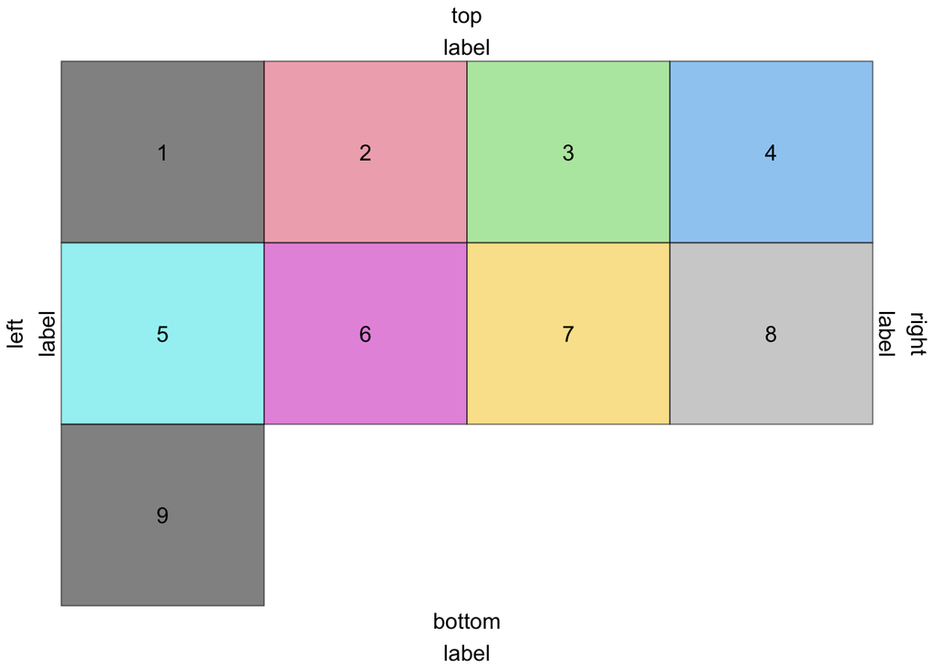

```r
dummy_grob <- function(id)  {
  grobTree(rectGrob(gp=gpar(fill=id, alpha=0.5)), textGrob(id))
}
gs <- lapply(1:9, dummy_grob)
grid.arrange(ncol=4, grobs=gs,
               top="top\nlabel", bottom="bottom\nlabel",
               left="left\nlabel", right="right\nlabel")
```

# R MacOS

## Matrix Operations

- [Which BLAS library is used by R?](https://cran.r-project.org/bin/macosx/RMacOSX-FAQ.html#Which-BLAS-is-used-and-how-can-it-be-changed_003f)
- [Using the faster veclib dynamically linked library](https://gist.github.com/nicebread/6920c8287d7bffb03007)
- [A tutorial/discussion from 2019 about rebuilding R binary with openBLAS and openMP](https://www.btskinner.io/code/install-r-with-openblas-and-openmp-on-macos-mojave/)

Of note, R binary versus the CRAN version of the R binary have different libraries bundled together. For older versions of Rstudio, there is a BLAS library that is provided with Apple that sometimes is faster. Ultimately, R will look for a symlinked library in the `lib/` folder.

```bash
# Install openblas
brew install openblas

# Some potentially useful symlinking commands
ln -sf /usr/local/opt/openblas/lib/libopenblas.dylib /usr/local/Cellar/r/4.1.2/lib/R/lib/libRblas.dylib
ln -sf /usr/local/opt/openblas/lib/libopenblas.dylib /usr/local/Cellar/r/4.1.2/lib/libRblas.dylib
```

# Metaprogramming

## Expressions

- constants
- symbols

```r
library(rlang)
# two ways of creating a symbol
sym("x") # symbol
```

```
## x
```

```r
class(expr(x)) # symbol
```

```
## [1] "name"
```

```r
quo(x)
```

```
## <quosure>
## expr: ^x
## env:  global
```

```r
?quo
```

[output not shown]

```r
expr("x") # expression
```

```
## [1] "x"
```

```r
as_string(sym("x"))
```

```
## [1] "x"
```

```r
as_name(sym("x")) # character
```

```
## [1] "x"
```

```r
class(as_name("x")) # character
```

```
## [1] "character"
```

## Quosures

Quosures are special type of *defused expression* that also keeps track of the original context the expression was written in.

### quo

`quo is used to capture local expressions, and also track the environment the expression was written.

### enquo

`enquo` is used to defuse function arguments, the `{{` is short for this common pattern. The arguments need to be defused because otherwise R will try to evaluate the expression in its orginal environment.

```r
my_function <- function(var) {
  var <- enquo(var)
  their_function(!!var)
}

# Equivalently
my_function <- function(var) {
  their_function({{ var }})
}
```